# Exploratory Data Analysis & Predictive Text App Roadmap

Data Science Capstone

November 15, 2026

## 1. Corpus Overview & Summary Statistics

The raw dataset comes from publicly crawled web text across three distinct communication styles. Note that the news file required binary-mode reading to prevent premature truncation from embedded special characters, and embedded null bytes were stripped from Twitter records.

Table 1: Summary Metrics Across US English Text Corpora

| Source | Disk Size (MB) | Line Count | Total Characters | Mean Words / Line | Median Words / Line | Max Words / Line |
| --- | --- | --- | --- | --- | --- | --- |
| Blogs | 200.42 | 899,288 | 206,824,382 | 41.8 | 28 | 6,726 |
| News | 196.28 | 1,010,242 | 203,223,154 | 34.4 | 32 | 1,796 |
| Twitter | 159.36 | 2,360,148 | 162,096,241 | 12.8 | 12 | 47 |

### Key Data Observations

- **Volume vs. Entry Count:** All three files contain roughly comparable character volumes (162M to 207M characters), yet Twitter contains more than double the number of lines (2.36M) compared to Blogs (899k) and News (1.01M).
- **Line Independence:** Because the source corpus splits documents into anonymized individual lines, each line is treated as an independent boundary during modeling so word sequences never bleed across unrelated entries.

## 2. Visual Exploration: Entry Length & Vocabulary Coverage

### Word Count Distributions by Source

The histograms below compare entry lengths across sources (capped at 150 words on the horizontal axis to highlight core distributions). Blogs and news show right-tailed distributions stretching into long articles, while Twitter clusters tightly below 30 words.

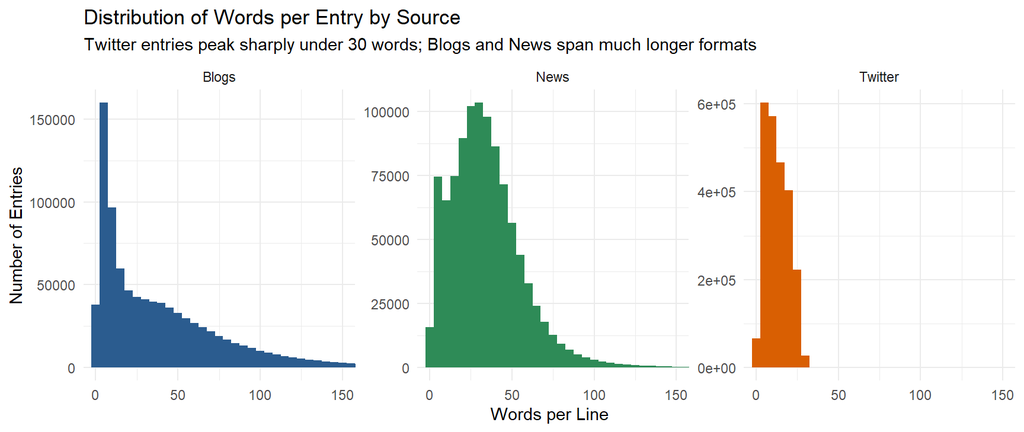

### N-Gram Frequencies & Dictionary Coverage

Using a 5% random sample (~213,000 lines), we normalized punctuation and smart quotes, converted text to lowercase, and replaced profanity with boundary markers so offensive phrases are never learned or suggested. We retained common stopwords (*the*, *to*, *and*) because they are essential for natural keyboard prediction.

Table 2: Top 10 Most Frequent Word Sequences (5% Sample)

| Rank | Top Unigram | Unigram Count | Top Bigram | Bigram Count | Top Trigram | Trigram Count |
| --- | --- | --- | --- | --- | --- | --- |
| 1 | the | 238,106 | of the | 21,133 | one of the | 1,713 |
| 2 | to | 137,365 | in the | 20,503 | a lot of | 1,541 |
| 3 | and | 120,646 | to the | 10,578 | thanks for the | 1,227 |
| 4 | a | 119,734 | for the | 10,063 | to be a | 894 |
| 5 | of | 100,445 | on the | 9,620 | going to be | 829 |
| 6 | i | 83,475 | to be | 7,953 | the end of | 738 |
| 7 | in | 82,126 | at the | 6,983 | it was a | 736 |
| 8 | for | 55,293 | and the | 6,316 | i want to | 724 |
| 9 | is | 53,786 | in a | 5,958 | out of the | 722 |
| 10 | that | 52,025 | with the | 5,314 | some of the | 687 |

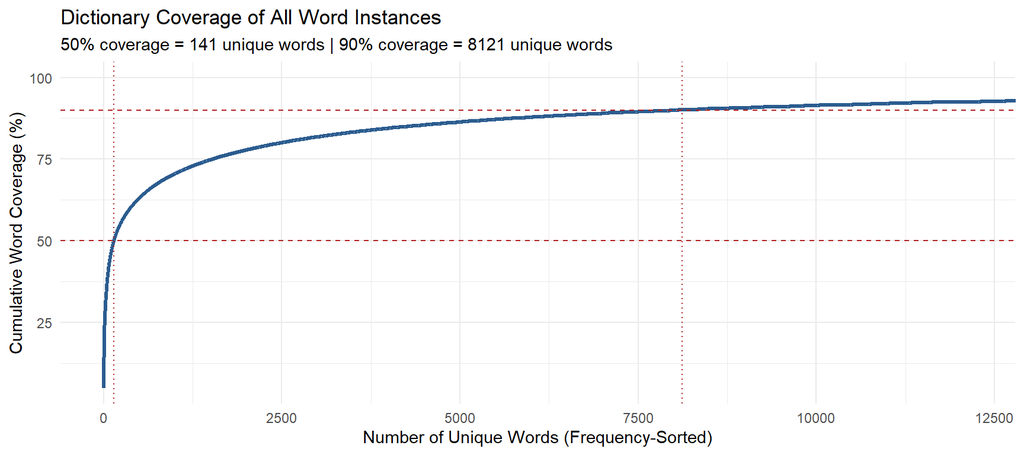

## 3. Prediction Algorithm & Shiny App Roadmap

Our objective is to deploy a responsive, smartphone-style next-word prediction app on **shinyapps.io**.

### Predictive Engine Design

1. **Multi-Level N-Gram Lookup (1- to 4-Grams):** The model stores the top 3 most probable next words for observed 1-, 2-, and 3-word contexts in indexed `data.table` structures, keeping the entire model under **25 MB** of RAM.
2. **Backoff Logic for Unseen Phrases:** When a user types a phrase, the engine checks 4-gram matches first (using the last 3 words). If fewer than 3 suggestions are found, it automatically “backs off” to 3-grams, 2-grams, and finally high-frequency unigrams so a sensible prediction is always returned.
3. **Noise & Profanity Safeguards:** Single-character artifacts (other than *“a”* and *“i”*) and offensive words are excluded prior to building lookup tables.

### Planned Shiny App Experience & Validation

- **Interactive Text Input & Quick-Select Buttons:** Users type into a clean text box and see the top 3 predicted next words rendered as clickable buttons that append directly to their sentence.
- **Benchmarking Before Launch:** Prior to final deployment, we will evaluate the model against a held-out validation set to verify **Top-1 and Top-3 prediction accuracy** alongside **millisecond-level response latency**.